# Assignment 5A: Airline Delays

Tenzin Lhamo Thakuri

2026-09-30

## Task

Submitted data file with at least some count analysis (+45)

Recreated File in Same Format as given, including missing data where there were empty cells in source data. (+5)

Placed file in Internet-accessible location, such as a publicly-accessible GitHub repo. Also OK (if less scalable) to generated and populated data frame from code. (+5)

Provided code to populate missing data. (+5)

Transformed data from wide to long format. (+10)

Compared percentage (not just counts) of either delays or arrival rates for two airlines overall. [Either with a chart, or a table; both would be exemplary]. Include text summarizes findings from this comparison. (+10)

Compared percentage (not just counts) of either delays or arrival rates for two airlines across five cities. [Either with a chart, or a table; both would be exemplary]. Include text summarizes findings from this comparison. (+10)

Describe discrepancy between comparing two airlines’ flight performances city-by-city and overall. (+5)

Assignment Tidying and Transforming Data

Explain discrepancy between comparing two airlines’ flight performances city-by-city and overall.(+5)

## Approach

Step 1: Create database and table to insert given two airlines delay data (wide structure data) in postgreSQL. Step 2: Connect R to PostgreSQL Step 3: Read a SQL table into R Step 4: Save the SQL table as CSV Step 5: Read wide structure data from github into R. Step 6: Transform wide data to long structure data. Step 7: Compare two airlines arrival delays across five cities using plot percentage

## Anticipated Challenges

converting wide structure data to long structure. Making comparison between two airlines across all cities.

## Code Base

### Load necessary libraries

```r
library(DBI)
library(RPostgres)
library(tidyverse)
```

### Create Database, Table, and Insert Data

The following SQL code creates the airlines_arrival_delay table, inserts the data provided in the assignment, and displays all the records in the table.

CREATE TABLE airlines_arrival_delay(“airline” VARCHAR(50), status VARCHAR(50), los_angeles Int,phoenix Int, san_diego Int,san_francisco Int,seattle Int); INSERT INTO airlines_arrival_delay(airline,status,los_angeles,phoenix,san_diego,san_francisco,seattle)VALUES (‘ALASKA’,‘on time’,497,221,212,503,1841), (NULL,‘delayed’,62,12,20,102,305), (NULL, NULL, NULL, NULL, NULL, NULL, NULL), (‘AMWEST’,‘on time’,694,4840,383,320,201), (NULL,‘delayed’,117,415,65,129,61); SELECT * FROM airlines_arrival_delay;

### Connect R to PostgreSQL

```r
con <- dbConnect(
  RPostgres::Postgres(),
  dbname = "Airlines_delay",
  host = "localhost",
  port = 5432,
  user = "postgres",
  password = Sys.getenv("DB_PASSWORD")
)
```

```r
dbListTables(con)
```

```
## [1] "airlines_arrival_delay"
```

```r
airlines_df <- dbReadTable(con, "airlines_arrival_delay")
head(airlines_df)
```

```
##   airline  status los_angeles phoenix san_diego san_francisco seattle
## 1  ALASKA on time         497     221       212           503    1841
## 2    <NA> delayed          62      12        20           102     305
## 3    <NA>    <NA>          NA      NA        NA            NA      NA
## 4  AMWEST on time         694    4840       383           320     201
## 5    <NA> delayed         117     415        65           129      61
```

```r
#set first and second columns name empty.
names(airlines_df)[1:2] <- c(" ", " ")
write.csv(airlines_df, file="airlines_arrival_delay.csv", row.names = FALSE)
```

### Load airline arrival delay dataset

```r
url<-"https://raw.githubusercontent.com/lhamo07/Data-607-Assignment/refs/heads/main/Assignment-5A/airlines_arrival_delay.csv"
airlines_arrival_delay_df<-read.csv(file=url)
airlines_arrival_delay_df
```

```
##       X.    X..1 los_angeles phoenix san_diego san_francisco seattle
## 1 ALASKA on time         497     221       212           503    1841
## 2   <NA> delayed          62      12        20           102     305
## 3   <NA>    <NA>          NA      NA        NA            NA      NA
## 4 AMWEST on time         694    4840       383           320     201
## 5   <NA> delayed         117     415        65           129      61
```

Rename the first two un-labelled columns as “airline” and “status”

```r
colnames(airlines_arrival_delay_df)[1:2] <- c("airline", "status")
airlines_arrival_delay_df
```

```
##   airline  status los_angeles phoenix san_diego san_francisco seattle
## 1  ALASKA on time         497     221       212           503    1841
## 2    <NA> delayed          62      12        20           102     305
## 3    <NA>    <NA>          NA      NA        NA            NA      NA
## 4  AMWEST on time         694    4840       383           320     201
## 5    <NA> delayed         117     415        65           129      61
```

```r
airline_long_structure<-airlines_arrival_delay_df%>%
  fill(airline)%>%
  pivot_longer(cols=!(airline:status),
               names_to="city",
               values_to="flight_count",
                   values_drop_na = TRUE

               )
airline_long_structure
```

```
## # A tibble: 20 × 4
##    airline status  city          flight_count
##    <chr>   <chr>   <chr>                <int>
##  1 ALASKA  on time los_angeles            497
##  2 ALASKA  on time phoenix                221
##  3 ALASKA  on time san_diego              212
##  4 ALASKA  on time san_francisco          503
##  5 ALASKA  on time seattle               1841
##  6 ALASKA  delayed los_angeles             62
##  7 ALASKA  delayed phoenix                 12
##  8 ALASKA  delayed san_diego               20
##  9 ALASKA  delayed san_francisco          102
## 10 ALASKA  delayed seattle                305
## 11 AMWEST  on time los_angeles            694
## 12 AMWEST  on time phoenix               4840
## 13 AMWEST  on time san_diego              383
## 14 AMWEST  on time san_francisco          320
## 15 AMWEST  on time seattle                201
## 16 AMWEST  delayed los_angeles            117
## 17 AMWEST  delayed phoenix                415
## 18 AMWEST  delayed san_diego               65
## 19 AMWEST  delayed san_francisco          129
## 20 AMWEST  delayed seattle                 61
```

First, I used fill(airline) to fill in the missing airline names with the corresponding airline name above. Then, I used pivot_longer() to convert the data from a wide structure to a long structure. In cols = !(airline:status), all columns except the columns from airline through status are selected for transformation. The selected column names are stored in the new city column using names_to = “city”, and their corresponding values are stored in the flight_count column using values_to = “flight_count”. Finally, values_drop_na = TRUE removes rows where the flight count value is missing NA ### Percentage of delays rates for ALASKA airlines

```r
alaska_summary<-airline_long_structure%>%
filter(airline=="ALASKA")%>%
  summarize(
    airline="ALASKA",
    total_delayed=sum(flight_count[status=='delayed']),
    total_on_time = sum(flight_count[status == "on time"]),
    grand_total   = total_delayed + total_on_time,
    delay_percent = round((total_delayed / grand_total) * 100,digits=2)
    )
alaska_summary
```

```
## # A tibble: 1 × 5
##   airline total_delayed total_on_time grand_total delay_percent
##   <chr>           <int>         <int>       <int>         <dbl>
## 1 ALASKA            501          3274        3775          13.3
```

### Percentage of delays rates for AMWEST airlines

```r
amwest_summary<-airline_long_structure%>%
filter(airline=="AMWEST")%>%
  summarize(
    airline="AMWEST",
    total_delayed=sum(flight_count[status=='delayed']),
    total_on_time = sum(flight_count[status == "on time"]),
    grand_total   = total_delayed + total_on_time,
    delay_percent = round((total_delayed / grand_total) * 100,digits=2)
    )
amwest_summary
```

```
## # A tibble: 1 × 5
##   airline total_delayed total_on_time grand_total delay_percent
##   <chr>           <int>         <int>       <int>         <dbl>
## 1 AMWEST            787          6438        7225          10.9
```

```r
percentage_summary<-bind_rows(alaska_summary,amwest_summary)
percentage_summary
```

```
## # A tibble: 2 × 5
##   airline total_delayed total_on_time grand_total delay_percent
##   <chr>           <int>         <int>       <int>         <dbl>
## 1 ALASKA            501          3274        3775          13.3
## 2 AMWEST            787          6438        7225          10.9
```

### Compared percentage of delays rates for two airlines overall.

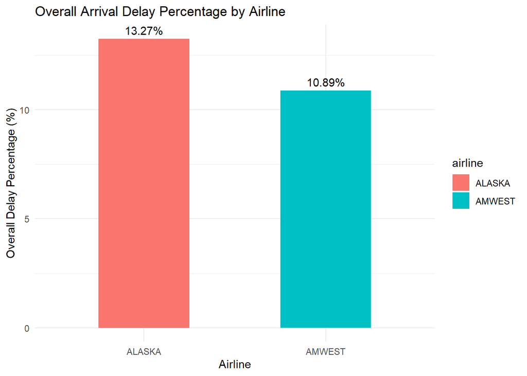

```r
ggplot(percentage_summary,aes(x=airline,y=delay_percent,fill=airline))+
  geom_col(width=0.5)+
   geom_text(
    aes(label = paste0(delay_percent, "%")),
    vjust = -0.5)+
    labs(
      title = "Overall Arrival Delay Percentage by Airline",
    x = "Airline",
    y = "Overall Delay Percentage (%)"
    )+
    theme_minimal()
```

### Compared percentage of delays rates for two airlines across five cities.

```r
city_summary<-airline_long_structure%>%
group_by(airline,city)%>%
    mutate(city_total=sum(flight_count),
           delay_percentage=round((flight_count/city_total)*100,digits=2))%>%


  filter(status=="delayed")


city_summary
```

```
## # A tibble: 10 × 6
## # Groups:   airline, city [10]
##    airline status  city          flight_count city_total delay_percentage
##    <chr>   <chr>   <chr>                <int>      <int>            <dbl>
##  1 ALASKA  delayed los_angeles             62        559            11.1
##  2 ALASKA  delayed phoenix                 12        233             5.15
##  3 ALASKA  delayed san_diego               20        232             8.62
##  4 ALASKA  delayed san_francisco          102        605            16.9
##  5 ALASKA  delayed seattle                305       2146            14.2
##  6 AMWEST  delayed los_angeles            117        811            14.4
##  7 AMWEST  delayed phoenix                415       5255             7.9
##  8 AMWEST  delayed san_diego               65        448            14.5
##  9 AMWEST  delayed san_francisco          129        449            28.7
## 10 AMWEST  delayed seattle                 61        262            23.3
```

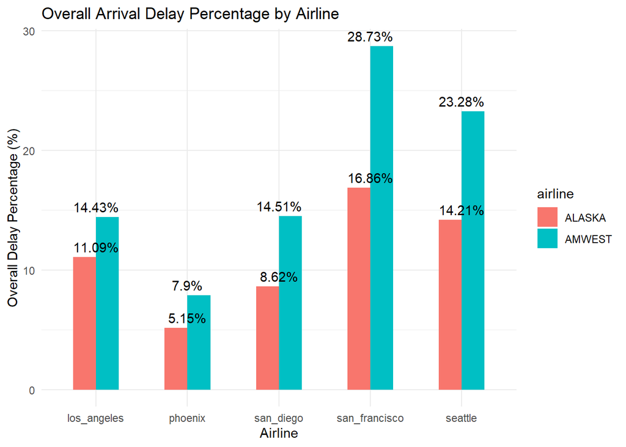

```r
ggplot(city_summary,aes(x=city,y=delay_percentage,fill=airline))+
  geom_col(width=0.5,position="dodge")+
  geom_text(
    aes(label = paste0(delay_percentage, "%")),
    vjust = -0.5)+
    labs(
      title = "Overall Arrival Delay Percentage by Airline",
    x = "Airline",
    y = "Overall Delay Percentage (%)"
    )+

    theme_minimal()
```

## Conclusion

### citation

https://chatgpt.com/share/6abc7bac-d99c-83e9-a515-e584ba7ef430 https://chatgpt.com/share/6ac2d87e-7cb8-83ea-899e-9e8371c0fbb0 OpenAI. (2026). ChatGPT [Large language model]. https://chatgpt.com. Accessed October 4, 2026.